# Uncovering Relationships

## overview

- cross validation with trainControl
- xgboost (along with other models)
- information leaks
- feature importance
- partial dependence
- the point of it all

## about me

- jen clark
- data scientist at benefitfocus
- main area of research: consumer behavior & industry trends

## trainControl

- pro: quick, painless, ready to go in a few minutes
- pro: highly customizable
- pro: mistakes and leaks are easy to spot
- con: ?

## trainControl code

```r
#downSample to create a balanced problem
data <- downSample(Alzheimers, Alzheimers$response)

#create a vector with predictors
y <- data$response

#drop predictor variable from dataset
data <- select(data, -response,-Class, -gender, -Genotype)

#set trainControl with customizable arguments
cv <- trainControl(method='cv',verboseIter=T, classProbs=TRUE)
#method boot, repeatedcv, repeated training/test splits, etc.
#verboseIter prints a training log
#classProbs class probablities are computed for classification models in each resample
```

## caret models, including xgBoost

- pro: large variety of models (https://topepo.github.io/caret/modelList.html)
- pro: test a handful all at once and compare
- con: depending on tuning parameters, can take a while to run
- focus here on eXtreme Gradient Boosting = xgbTree or xgbLinear
  - (Stochastic Gradient Boosting = gbm & Random Forest = rf)
  - supports regression, classification, and ranking
  - it’s fast & accepts sparse input
  - http://xgboost.readthedocs.io/en/latest/R-package/xgboostPresentation.html

## caret modeling using train

```r
models <- list()
models[['rf']]     <- train(data, y, method='rf',     trControl=cv, tuneLength=3)
models[['rpart']]     <- train(data, y, method='rpart',  trControl=cv, tuneLength=10)
models[['gbm']] <- train(data, y, method='gbm', trControl=cv, tuneLength=10)
models[['xgboost']] <- train(data, y, method='xgbTree', trControl=cv, tuneLength=10)
```

```
## Fitting nrounds = 200, max_depth = 5, eta = 0.3, gamma = 0, colsample_bytree = 0.6, min_child_weight = 1 on full training set
```

```r
models[['earth']] <- train(data, y, method='earth', trControl=cv, tuneLength=3)
```

## let’s check our accuracy

```r
accuracy <- names(models) %>%          # For each model name,
  lapply(function(model.name) {        # apply a function that will use that name to
    models[[model.name]]$resample %>%  # fetch a data frame containing cross validation accuracy,
      mutate(Model=model.name)         # attach the model name to that data frame,
  }) %>% do.call(rbind, .)            # and then merge results for all models together

#credit: Eric Czech
```

## we’ve got a leak

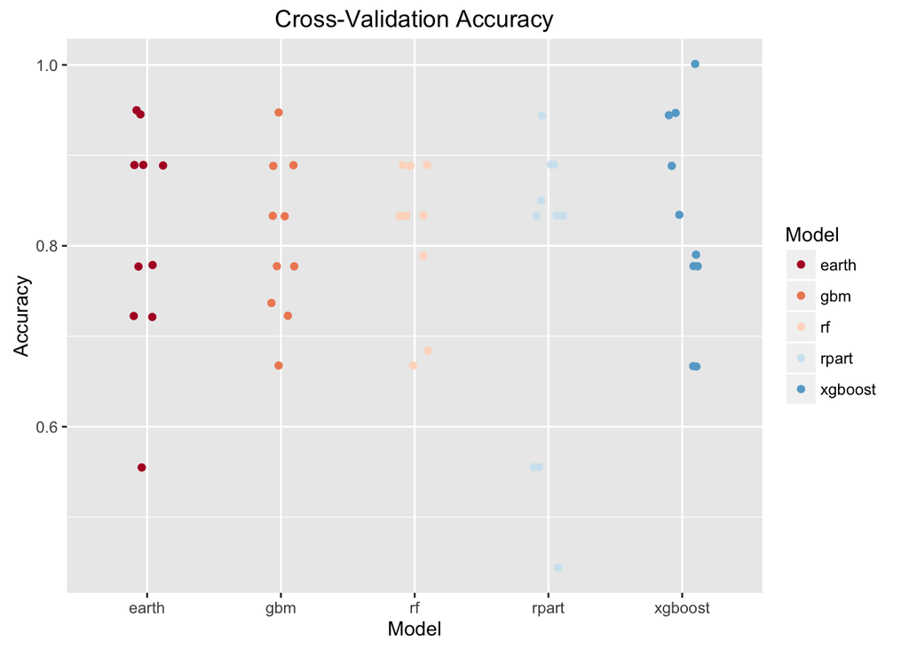

```r
colors <- c('#b2182b','#ef8a62','#fddbc7','#d1e5f0','#67a9cf','#2166ac')
#[from ColorBrewer: http://colorbrewer2.org/#type=diverging&scheme=RdBu&n=6]

#plot our iterations
accuracy %>%
  ggplot(aes(x=Model, y=Accuracy, color=Model)) +
  geom_jitter(width=.3) +
  ggtitle('Cross-Validation Accuracy') + scale_color_manual(values=colors)
```

```r
#credit: Eric Czech
```

## we fixed it b/c this process is awesome

```
## Fitting nrounds = 50, max_depth = 1, eta = 0.3, gamma = 0, colsample_bytree = 0.6, min_child_weight = 1 on full training set
```

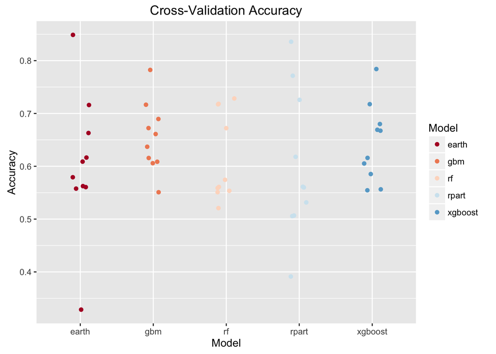

## Feature Importance

- pro: automatically select the features that are most relevant
- pro: automatically calculated for caret models, including rf, gbm, and xgboost
- pro: highlight an unexpected feature
- con: list can be difficult to interpret

## varImp

```r
varImp(models2[['xgboost']])
```

```
## xgbTree variable importance
##
##                                  Overall
## TRAIL_R3                         100.000
## Thrombopoietin                    93.110
## Sortilin                          55.680
## Cortisol                          50.292
## Beta_2_Microglobulin              23.945
## Ferritin                          21.224
## SGOT                              19.081
## VCAM_1                            14.884
## IgA                               10.753
## Pulmonary_and_Activation_Regulat  10.332
## Complement_Factor_H                9.208
## Tissue_Factor                      3.478
## CD5L                               3.323
## LOX_1                              2.880
## Adiponectin                        1.824
## Lipoprotein_a                      0.000
```

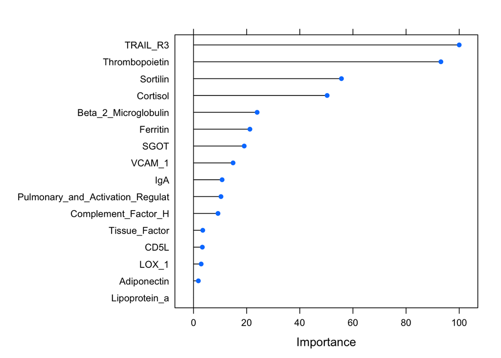

```r
plot(varImp(models2[['xgboost']]))
```

## Partial Dependence

- pro: INTERPRETABILITY
- pro: understand new relationships in the data
- con: can be misleading with higher-order hidden interactions
- pro/con: more difficult to reduce down to a sound-bite

## plot partial dependence

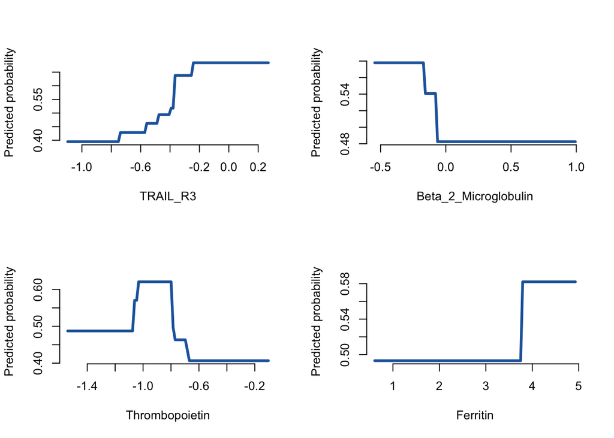

```r
#set plot boxes
par(mfrow=c(2,2))
#set color, line width, and supress the box around the plot
par(col=colors[6], lwd=3, bty="n")
#plot the partial dependence
plot(models2[['gbm']]$finalModel, 'TRAIL_R3', type="response")
plot(models2[['gbm']]$finalModel, 'Beta_2_Microglobulin', type="response")
plot(models2[['gbm']]$finalModel, 'Thrombopoietin', type="response")
plot(models2[['gbm']]$finalModel, 'Ferritin', type="response")
```

## point of it all

- easy, painless process to quickly get to know your data in a different light
- great for inspiration
- great when you don’t need a “perfect” model